# Hvordan læses stykkerne ind i R?

pmd

Stykkerne er i TEI format. Dette format har ikke en standard indlæsningsmetod til R. Derfor transformerer vi TEI filerne over i et format der bedre passer til R. Vi har her valgt JSONL, men kunne have valgt andre formater. I JSONL formatet er hver linie i sig selv en stump valid JSON, mens filen som et hele ikke er valid JSON. Dette gør, at hver linie kan læses uafhængigt af hele filen.

For at gøre dette nemt, har vi skrevet to små R funktioner. En der transformerer alle TEI filer i en mappe og en der indlæser alle JSONL filer i en mappe til R. TEI filer er identificeret ved at deres filnavn ender med “.page”.

Denne notebook illustrerer brugen af disse to funktioner.

Før vi starter skal vi indlæse de nødvendige udvidelsespakker til R.

```r
library(tidyverse)
library(ndjson)
library(here)
library(fs)
library(xslt)
```

De to hjælpefunktioner er defineret i `src/p017-functions.R`, som vi indlæser på følgende vis

```r
source(here("src", "p017-functions.R"))
```

# Transformation af TEI filer

```r
my_dir <-"test-data"
dir_ls(here(my_dir))
```

```
/home/baj/Projects/P017_R_Project/test-data/Abracadabra_mod.jsonl
/home/baj/Projects/P017_R_Project/test-data/Abracadabra_mod.page
/home/baj/Projects/P017_R_Project/test-data/Barselstuen_mod.jsonl
/home/baj/Projects/P017_R_Project/test-data/Barselstuen_mod.page
/home/baj/Projects/P017_R_Project/test-data/Bondedreng_mod.jsonl
/home/baj/Projects/P017_R_Project/test-data/Bondedreng_mod.page
/home/baj/Projects/P017_R_Project/test-data/Brudgom_mod.jsonl
/home/baj/Projects/P017_R_Project/test-data/Brudgom_mod.page
/home/baj/Projects/P017_R_Project/test-data/De_u-synlige_mod.jsonl
/home/baj/Projects/P017_R_Project/test-data/De_u-synlige_mod.page
/home/baj/Projects/P017_R_Project/test-data/Den_11_Junii_mod.jsonl
/home/baj/Projects/P017_R_Project/test-data/Den_11_Junii_mod.page
/home/baj/Projects/P017_R_Project/test-data/Den_Honnette_Ambition_mod.jsonl
/home/baj/Projects/P017_R_Project/test-data/Den_Honnette_Ambition_mod.page
/home/baj/Projects/P017_R_Project/test-data/Den_Stundesloese_mod.jsonl
/home/baj/Projects/P017_R_Project/test-data/Den_Stundesloese_mod.page
/home/baj/Projects/P017_R_Project/test-data/Den_Vaegelsindede_1723_mod.jsonl
/home/baj/Projects/P017_R_Project/test-data/Den_Vaegelsindede_1723_mod.page
/home/baj/Projects/P017_R_Project/test-data/Den_Vaegelsindede_1731_mod.jsonl
/home/baj/Projects/P017_R_Project/test-data/Den_Vaegelsindede_1731_mod.page
/home/baj/Projects/P017_R_Project/test-data/Det_Arabiske_Pulver_mod.jsonl
/home/baj/Projects/P017_R_Project/test-data/Det_Arabiske_Pulver_mod.page
/home/baj/Projects/P017_R_Project/test-data/Diderich_mod.jsonl
/home/baj/Projects/P017_R_Project/test-data/Diderich_mod.page
/home/baj/Projects/P017_R_Project/test-data/Erasmus_mod.jsonl
/home/baj/Projects/P017_R_Project/test-data/Erasmus_mod.page
/home/baj/Projects/P017_R_Project/test-data/Fortale_1723_mod.jsonl
/home/baj/Projects/P017_R_Project/test-data/Fortale_1723_mod.page
/home/baj/Projects/P017_R_Project/test-data/Fortale_1731_mod.jsonl
/home/baj/Projects/P017_R_Project/test-data/Fortale_1731_mod.page
/home/baj/Projects/P017_R_Project/test-data/GertWestphaler1723_mod.jsonl
/home/baj/Projects/P017_R_Project/test-data/GertWestphaler1723_mod.page
/home/baj/Projects/P017_R_Project/test-data/GertWestphaler1724_mod.jsonl
/home/baj/Projects/P017_R_Project/test-data/GertWestphaler1724_mod.page
/home/baj/Projects/P017_R_Project/test-data/Henrick_og_Pernille_mod.jsonl
/home/baj/Projects/P017_R_Project/test-data/Henrick_og_Pernille_mod.page
/home/baj/Projects/P017_R_Project/test-data/Hexerie_mod.jsonl
/home/baj/Projects/P017_R_Project/test-data/Hexerie_mod.page
/home/baj/Projects/P017_R_Project/test-data/JJ_Bet_1723_mod.jsonl
/home/baj/Projects/P017_R_Project/test-data/JJ_Bet_1723_mod.page
```

[output cut: 28 more lines]

```
/home/baj/Projects/P017_R_Project/test-data/Plutus_mod.page
/home/baj/Projects/P017_R_Project/test-data/Ranudo_mod.jsonl
/home/baj/Projects/P017_R_Project/test-data/Ranudo_mod.page
/home/baj/Projects/P017_R_Project/test-data/Republiqven_mod.jsonl
/home/baj/Projects/P017_R_Project/test-data/Republiqven_mod.page
/home/baj/Projects/P017_R_Project/test-data/Sganarel_mod.jsonl
/home/baj/Projects/P017_R_Project/test-data/Sganarel_mod.page
/home/baj/Projects/P017_R_Project/test-data/Skibbrud_mod.jsonl
/home/baj/Projects/P017_R_Project/test-data/Skibbrud_mod.page
/home/baj/Projects/P017_R_Project/test-data/Ulysses_mod.jsonl
/home/baj/Projects/P017_R_Project/test-data/Ulysses_mod.page
/home/baj/Projects/P017_R_Project/test-data/aviser
/home/baj/Projects/P017_R_Project/test-data/mygraph.png
/home/baj/Projects/P017_R_Project/test-data/uden_hoved_og_hale_mod.jsonl
/home/baj/Projects/P017_R_Project/test-data/uden_hoved_og_hale_mod.page
```

```r
convert_TEI_to_JSONL(here(my_dir))
```

```r
dir_ls(here(my_dir))
```

```
/home/baj/Projects/P017_R_Project/test-data/Abracadabra_mod.jsonl
/home/baj/Projects/P017_R_Project/test-data/Abracadabra_mod.page
/home/baj/Projects/P017_R_Project/test-data/Barselstuen_mod.jsonl
/home/baj/Projects/P017_R_Project/test-data/Barselstuen_mod.page
/home/baj/Projects/P017_R_Project/test-data/Bondedreng_mod.jsonl
/home/baj/Projects/P017_R_Project/test-data/Bondedreng_mod.page
/home/baj/Projects/P017_R_Project/test-data/Brudgom_mod.jsonl
/home/baj/Projects/P017_R_Project/test-data/Brudgom_mod.page
/home/baj/Projects/P017_R_Project/test-data/De_u-synlige_mod.jsonl
/home/baj/Projects/P017_R_Project/test-data/De_u-synlige_mod.page
/home/baj/Projects/P017_R_Project/test-data/Den_11_Junii_mod.jsonl
/home/baj/Projects/P017_R_Project/test-data/Den_11_Junii_mod.page
/home/baj/Projects/P017_R_Project/test-data/Den_Honnette_Ambition_mod.jsonl
/home/baj/Projects/P017_R_Project/test-data/Den_Honnette_Ambition_mod.page
/home/baj/Projects/P017_R_Project/test-data/Den_Stundesloese_mod.jsonl
/home/baj/Projects/P017_R_Project/test-data/Den_Stundesloese_mod.page
/home/baj/Projects/P017_R_Project/test-data/Den_Vaegelsindede_1723_mod.jsonl
/home/baj/Projects/P017_R_Project/test-data/Den_Vaegelsindede_1723_mod.page
/home/baj/Projects/P017_R_Project/test-data/Den_Vaegelsindede_1731_mod.jsonl
/home/baj/Projects/P017_R_Project/test-data/Den_Vaegelsindede_1731_mod.page
/home/baj/Projects/P017_R_Project/test-data/Det_Arabiske_Pulver_mod.jsonl
/home/baj/Projects/P017_R_Project/test-data/Det_Arabiske_Pulver_mod.page
/home/baj/Projects/P017_R_Project/test-data/Diderich_mod.jsonl
/home/baj/Projects/P017_R_Project/test-data/Diderich_mod.page
/home/baj/Projects/P017_R_Project/test-data/Erasmus_mod.jsonl
/home/baj/Projects/P017_R_Project/test-data/Erasmus_mod.page
/home/baj/Projects/P017_R_Project/test-data/Fortale_1723_mod.jsonl
/home/baj/Projects/P017_R_Project/test-data/Fortale_1723_mod.page
/home/baj/Projects/P017_R_Project/test-data/Fortale_1731_mod.jsonl
/home/baj/Projects/P017_R_Project/test-data/Fortale_1731_mod.page
/home/baj/Projects/P017_R_Project/test-data/GertWestphaler1723_mod.jsonl
/home/baj/Projects/P017_R_Project/test-data/GertWestphaler1723_mod.page
/home/baj/Projects/P017_R_Project/test-data/GertWestphaler1724_mod.jsonl
/home/baj/Projects/P017_R_Project/test-data/GertWestphaler1724_mod.page
/home/baj/Projects/P017_R_Project/test-data/Henrick_og_Pernille_mod.jsonl
/home/baj/Projects/P017_R_Project/test-data/Henrick_og_Pernille_mod.page
/home/baj/Projects/P017_R_Project/test-data/Hexerie_mod.jsonl
/home/baj/Projects/P017_R_Project/test-data/Hexerie_mod.page
/home/baj/Projects/P017_R_Project/test-data/JJ_Bet_1723_mod.jsonl
/home/baj/Projects/P017_R_Project/test-data/JJ_Bet_1723_mod.page
```

[output cut: 28 more lines]

```
/home/baj/Projects/P017_R_Project/test-data/Plutus_mod.page
/home/baj/Projects/P017_R_Project/test-data/Ranudo_mod.jsonl
/home/baj/Projects/P017_R_Project/test-data/Ranudo_mod.page
/home/baj/Projects/P017_R_Project/test-data/Republiqven_mod.jsonl
/home/baj/Projects/P017_R_Project/test-data/Republiqven_mod.page
/home/baj/Projects/P017_R_Project/test-data/Sganarel_mod.jsonl
/home/baj/Projects/P017_R_Project/test-data/Sganarel_mod.page
/home/baj/Projects/P017_R_Project/test-data/Skibbrud_mod.jsonl
/home/baj/Projects/P017_R_Project/test-data/Skibbrud_mod.page
/home/baj/Projects/P017_R_Project/test-data/Ulysses_mod.jsonl
/home/baj/Projects/P017_R_Project/test-data/Ulysses_mod.page
/home/baj/Projects/P017_R_Project/test-data/aviser
/home/baj/Projects/P017_R_Project/test-data/mygraph.png
/home/baj/Projects/P017_R_Project/test-data/uden_hoved_og_hale_mod.jsonl
/home/baj/Projects/P017_R_Project/test-data/uden_hoved_og_hale_mod.page
```

# Indlæsning af JSONL filer til R

```r
read_plays_jsonl(here(my_dir)) -> plays
```

```
Parsing error on line 230
```

Lad os kort se på fx hvor mange rækker, vi har i hvert af de indlæste skuespil. Rækker er her ikke så meningsgivende, da det både kan være replikker og regibemærkninger. Lad os derfor også prøve at finde antal replikker og antal regibemærkninger!

Og antal sagte ord!

```r
# Tæl antal rækker
# Hvis vi bruger titel til at identificere de forskellige komedier,
# vil vi komme til at slå de to udgaver af "Den vægelsindede" sammen,
# og de to udgaver af "Mester Gert Westphaler".
# Det undgår vi ved at bruge fuld titel (docTitle) eller ved også at bruge årstal (year).
(plays %>%
  count(docTitle, year, name = "rækker") -> antal_rækker)
```

| docTitle | year | rækker |
| --- | --- | --- |
| Barselsstuen Komedie | (1724) | 1124 |
| De usynlige Komedie i 3 akter | (1731) | 471 |
| Den 11. juni | (1724) | 789 |
| Den danske komedies ligbegængelse Med Thaliæ afskedstale, forestillet til allersidste slutning af de danske aktører den 25. februar 1727 | (1746) | 86 |
| Den forvandlede brudgom Komedie i 1 akt uden aktører | (1753) | 270 |
| Den honnette ambition Komedie i 3 akter | (1731) | 617 |
| Den pantsatte bondedreng Komedie i 3 akter | (1731) | 483 |
| Den politiske kandestøber Komedie | (1723) | 695 |
| Den stundesløse Komedie i 3 akter | (1731) | 967 |
| Den vægelsindede Komedie | (1723) | 539 |

[output cut: 26 more lines]

[output not shown]

[output cut: 26 more lines]

```r
# Tæl antal sagte ord i stykket
(plays %>%
  mutate(n_spoken_words = str_count(spoke, '\\w+')) %>%
  # remove rows that are not dialogue
  filter(!is.na(spoke)) %>%
  # add the number of spoken words
  mutate(n_spoken_words = str_count(spoke, '\\w+')) %>%
  # group the play in scene_index and speaker, ignoring the test
  group_by(docTitle, year) %>%
  # sum the words spoken by each speaker
  summarise(words = sum(n_spoken_words), docTitle, year) %>%
  distinct() -> antal_ord)
```

| docTitle | year | words |
| --- | --- | --- |
| Barselsstuen Komedie | (1724) | 20877 |
| De usynlige Komedie i 3 akter | (1731) | 9708 |
| Den 11. juni | (1724) | 14736 |
| Den danske komedies ligbegængelse Med Thaliæ afskedstale, forestillet til allersidste slutning af de danske aktører den 25. februar 1727 | (1746) | 1430 |
| Den forvandlede brudgom Komedie i 1 akt uden aktører | (1753) | 4671 |
| Den honnette ambition Komedie i 3 akter | (1731) | 9561 |
| Den pantsatte bondedreng Komedie i 3 akter | (1731) | 7658 |
| Den politiske kandestøber Komedie | (1723) | 13084 |
| Den stundesløse Komedie i 3 akter | (1731) | 15944 |
| Den vægelsindede Komedie | (1723) | 13313 |

[output cut: 26 more lines]

```r
# Tæl antal regibemærkninger
# bemærk de findes på to niveauer, så i første omgang tæller vi dem hver for sig
# Tæl antal <stage>
(plays %>%
  filter(!is.na(stage)) %>% #filtrer stage markeret NA ud
  filter(!(stage == "")) %>% #filtrer tomme stage ud
  count(docTitle, year, name = "antal_stage") -> antal_stage)
```

| docTitle | year | antal_stage |
| --- | --- | --- |
| Barselsstuen Komedie | (1724) | 131 |
| De usynlige Komedie i 3 akter | (1731) | 29 |
| Den 11. juni | (1724) | 80 |
| Den danske komedies ligbegængelse Med Thaliæ afskedstale, forestillet til allersidste slutning af de danske aktører den 25. februar 1727 | (1746) | 8 |
| Den forvandlede brudgom Komedie i 1 akt uden aktører | (1753) | 28 |
| Den honnette ambition Komedie i 3 akter | (1731) | 41 |
| Den pantsatte bondedreng Komedie i 3 akter | (1731) | 37 |
| Den politiske kandestøber Komedie | (1723) | 82 |
| Den stundesløse Komedie i 3 akter | (1731) | 91 |
| Den vægelsindede Komedie | (1723) | 48 |

[output cut: 26 more lines]

```r
# Tæl antal <speaker_stage>
(plays %>%
  filter(!is.na(speaker_stage)) %>% #filtrer speaker_stage markeret NA ud
  filter(!(speaker_stage == "")) %>% #filtrer tomme speaker_stage ud
  count(docTitle, year, name = "antal_speaker_stage") -> antal_speaker_stage)
```

| docTitle | year | antal_speaker_stage |
| --- | --- | --- |
| Barselsstuen Komedie | (1724) | 54 |
| De usynlige Komedie i 3 akter | (1731) | 23 |
| Den 11. juni | (1724) | 46 |
| Den danske komedies ligbegængelse Med Thaliæ afskedstale, forestillet til allersidste slutning af de danske aktører den 25. februar 1727 | (1746) | 2 |
| Den forvandlede brudgom Komedie i 1 akt uden aktører | (1753) | 10 |
| Den honnette ambition Komedie i 3 akter | (1731) | 17 |
| Den pantsatte bondedreng Komedie i 3 akter | (1731) | 21 |
| Den politiske kandestøber Komedie | (1723) | 28 |
| Den stundesløse Komedie i 3 akter | (1731) | 72 |
| Den vægelsindede Komedie | (1723) | 15 |

[output cut: 26 more lines]

```r
# Tæl antal replikker
(plays %>%
  filter(!is.na(spoke)) %>% #filtrer replikker markeret NA ud
  filter(!(spoke == "")) %>% #filtrer tomme replikker ud
  count(docTitle, year, name = "replikker") -> antal_replikker)
```

# Visualisering af optællingerne

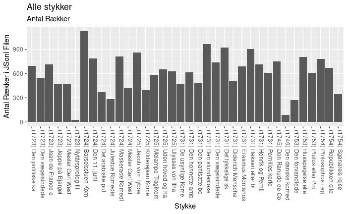

```r
antal_rækker %>%
  ggplot(aes(y = rækker, x = str_c(year, " ", str_sub(docTitle,0,16)))) +
  theme(axis.text.x = element_text(angle = -90, hjust = 0, vjust = 0)) +
    geom_bar(stat="identity") +
    theme(legend.position="bottom") +
    labs(
      title = "Alle stykker",
      subtitle = "Antal Rækker"
    ) +
  xlab("Stykke") +
  ylab("Antal Rækker i JSonl Filen")
ggsave(here("graphs/read-plays", "Optælling_af_rækker.pdf"))
```

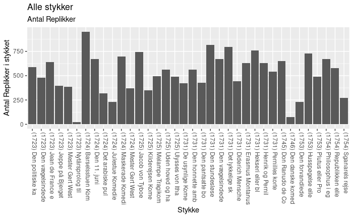

```r
antal_replikker %>%
  ggplot(aes(y = replikker, x = str_c(year, " ", str_sub(docTitle,0,16)))) +
  theme(axis.text.x = element_text(angle = -90, hjust = 0, vjust = 0)) +
    geom_bar(stat="identity") +
    theme(legend.position="bottom") +
    labs(
      title = "Alle stykker",
      subtitle = "Antal Replikker"
    ) +
  xlab("Stykke") +
  ylab("Antal Replikker i stykket")
ggsave(here("graphs/read-plays", "Optælling_af_replikker.pdf"))
```

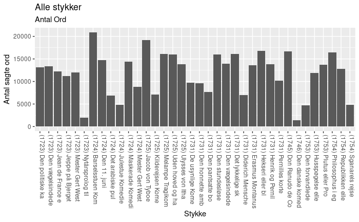

```r
antal_ord %>%
  ggplot(aes(y = words, x = str_c(year, " ", str_sub(docTitle,0,16)))) +
  theme(axis.text.x = element_text(angle = -90, hjust = 0, vjust = 0)) +
    geom_bar(stat="identity") +
    theme(legend.position="bottom") +
    labs(
      title = "Alle stykker",
      subtitle = "Antal Ord"
    ) +
  xlab("Stykke") +
  ylab("Antal sagte ord")

ggsave(here("graphs/read-plays", "Optælling_af_ord.pdf"))
```

# Indlæsning af en enkelt JSONL fil til R

Der har været noget bøvl med titler på stykkerne, som sjældent er hvad vi forventer, hvis de altså overhovedet er der, derfor har vi indført en funktion, som indlæser et enkelt stykke fra JSONL filen. Titlerne skulle fungere nu, men det er stadig rart med en funktion, som indlæser et enkelt stykke.

```r
#Funtionen her henter det skuespil, der er i den navngavne JSONL fil
read_play_jsonl(here(my_dir, "Den_Vaegelsindede_1731_mod.jsonl")) -> play
play #se den tbl, der nu er last ind i play
```

| filename | act | act_number | docTitle | index | scene | scene_number | speaker | speaker_stage | spoke | stage | title | type | year |
| --- | --- | --- | --- | --- | --- | --- | --- | --- | --- | --- | --- | --- | --- |
| Den_Vaegelsindede_1731_mod.jsonl | Første akt | 1 | Den vægelsindede Komedie i 3 akter | 1 | Scene 1 | 1 | NA | NA | NA | Helene, Leonore | Den vægelsindede | 1 | (1731) |
| Den_Vaegelsindede_1731_mod.jsonl | Første akt | 1 | Den vægelsindede Komedie i 3 akter | 2 | Scene 1 | 1 | Helene | NA | Tal aldrig derom, min kære jomfru, vi er lige vel faren begge, hvorvel vore opvartere er af stridige humeurs, så at jeg ved ikke hvo af os mest er at beklage. | NA | Den vægelsindede | 4 | (1731) |
| Den_Vaegelsindede_1731_mod.jsonl | Første akt | 1 | Den vægelsindede Komedie i 3 akter | 3 | Scene 1 | 1 | Leonore | NA | Det er uden tvivl jeg, thi enhver mandsperson der er dannet som hendes broder Eraste, kan fly et fruentimmer nok at bryde sit hoved med. Det lader som han elsker mig, men jeg kan forsikre hende at i a… | NA | Den vægelsindede | 4 | (1731) |
| Den_Vaegelsindede_1731_mod.jsonl | Første akt | 1 | Den vægelsindede Komedie i 3 akter | 4 | Scene 1 | 1 | Helene | NA | Hvad hendes broder Apicius angår, da kan jeg ikke sige at hans tale er forblommet. De allerprægtigste kærlighedserklæringer koster ham intet, men jeg ved ikke om jeg kan fæste mindste tro dertil, så u… | NA | Den vægelsindede | 4 | (1731) |
| Den_Vaegelsindede_1731_mod.jsonl | Første akt | 1 | Den vægelsindede Komedie i 3 akter | 5 | Scene 1 | 1 | Leonore | NA | Hun gør min tro vel deri, jomfru. Jeg skal min tro følge hendes eksempel. | NA | Den vægelsindede | 4 | (1731) |
| Den_Vaegelsindede_1731_mod.jsonl | Første akt | 1 | Den vægelsindede Komedie i 3 akter | 6 | Scene 1 | 1 | Helene | NA | Jeg tilstår vel at det er noget vanskeligt ganske at forlade den som man engang har gjort sig tanker om. | NA | Den vægelsindede | 4 | (1731) |
| Den_Vaegelsindede_1731_mod.jsonl | Første akt | 1 | Den vægelsindede Komedie i 3 akter | 7 | Scene 1 | 1 | Leonore | NA | Det er sandt nok. Men hvad er herved at gøre? | NA | Den vægelsindede | 4 | (1731) |
| Den_Vaegelsindede_1731_mod.jsonl | Første akt | 1 | Den vægelsindede Komedie i 3 akter | 8 | Scene 1 | 1 | Helene | NA | Jeg bilder mig ind at man nok skulle bringe dem på rette vej ved at forestille den ene hans alt for store ærbarhed og sparsommelighed, og at vise den anden hvor meget han lider formedelst hans flygtig… | NA | Den vægelsindede | 4 | (1731) |
| Den_Vaegelsindede_1731_mod.jsonl | Første akt | 1 | Den vægelsindede Komedie i 3 akter | 9 | Scene 1 | 1 | Leonore | NA | Ej, mon sådant ikke er sagt dem uden frugt hundrede gange tilforn? Jeg var tilfreds at monsieur Eraste var kendt med en vis dame som jeg talte med i går, som jeg ikke vil nævne. Jeg tror virkelig at d… | NA | Den vægelsindede | 4 | (1731) |
| Den_Vaegelsindede_1731_mod.jsonl | Første akt | 1 | Den vægelsindede Komedie i 3 akter | 10 | Scene 1 | 1 | Helene | NA | Hvor bor den dame? | NA | Den vægelsindede | 4 | (1731) |

[output cut: 731 more lines]

```r
NA
```

Og så tager vi lige den med antal replikker igen!

```r
# Tæl antal rækker
play %>% count(name = "# rækker")
```

| # rækker |
| --- |
| 741 |

```r
# Tæl antal replikker
play %>%
  filter(!is.na(spoke)) %>% #filtrer replikker markeret NA ud
  filter(!(spoke == "")) %>% #filtrer tomme replikker ud
  count(name = "# replikker")
```

| # replikker |
| --- |
| 673 |

```r
# Tæl antal regibemærkninger
# bemærk de findes på to niveauer, så i første omgang tæller vi dem hver for sig
# Tæl antal <stage>
play %>%
  filter(!is.na(stage)) %>% #filtrer stage markeret NA ud
  filter(!(stage == "")) %>% #filtrer tomme stage ud
  count(name = "# stage")
```

| # stage |
| --- |
| 50 |

```r
# Tæl antal <speaker_stage>
play %>%
  filter(!is.na(speaker_stage)) %>% #filtrer speaker_stage markeret NA ud
  filter(!(speaker_stage == "")) %>% #filtrer tomme speaker_stage ud
  count(name = "# speaker_stage")
```

| # speaker_stage |
| --- |
| 26 |